# Raster data

Carole Voulgaris

9/24/2021

This tutorial focuses on working with raster data. Most of the spatial data we’ve been working with in class so far has been vector data (points, polygons, and lines). The raster data you’ve worked with has been images, including basemap tiles from OpenStreetMaps and the historic map images you georeferenced in Assignment 2.

A raster layer is a matrix or grid with x and y values to indicate a location on a map and z value that indicates some other characteristics that can vary continuously across space. For an image file, the z value indicates a color (an image file is often three raster files indicating the degree of red, green, and blue, respectively). Other raster layers might contain different information, such as elevation, temperature, or air quality.

We will be working with the following packages for this tutorial:

```r
library(stars)
library(sf)
library(tidyverse)
library(osmextract)
library(tigris)
```

# Creating a raster layer from a polygon layer

In the Assignment 3 tutorial, we did create a grid containing values that varied continuously across space, but we stored it as a layer of polygons. Let’s load that layer now and convert it to a raster layer.

The polygon layer is a 100x100 grid, so I’ll use the same resolution for the raster layer.

I can use the `plot()` function to take a quick look at the raster.

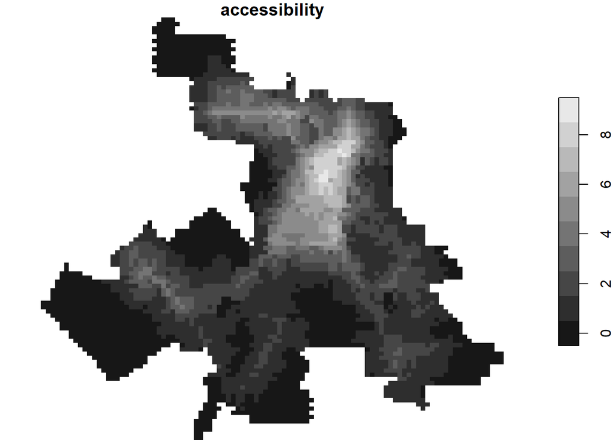

```r
access_poly <- st_read("SLO_access.geojson", quiet=TRUE)

access_raster <- st_rasterize(access_poly["accessibility"],
                              nx = 100, ny = 100)
plot(access_raster)
```

Or I can use ggplot to add it to a layer showing the street network

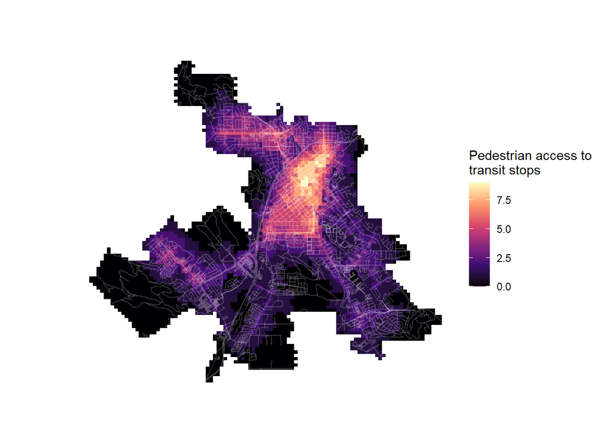

```r
SLO_city_limits <- places("California") %>%
  filter(NAME == "San Luis Obispo")

SLO_file <- oe_match("San Luis Obispo", quiet = TRUE)

SLO_streets <- oe_read(SLO_file$url,
                   provider = "openstreetmap_fr",
                   download_directory = "networks",
                   layer = "lines",
                   quiet = TRUE) %>%
  filter(!is.na(highway)) %>%
  st_transform(crs = st_crs(SLO_city_limits)) %>%
  st_filter(SLO_city_limits)

ggplot(SLO_streets) +
  geom_stars(data = access_raster) +
  geom_sf(color = "white", alpha = 0.2) +
  scale_fill_viridis_c(na.value = NA,
                       option="A",
                       name = "Pedestrian access to\ntransit stops") +
  theme_void()
```

It looks pretty similar to the polygon layer we used to create the raster, but you’ll notice that it takes up a lot less memory. Rasters are generally the most efficient way to store a single variable that varies continuously across space.

# Creating a vector layer from a raster layer

There are a few different ways you can create a vector layer from a raster layer.

## Points from grid cells

There might be a reason to create a point for each grid cell. You can do that using `st_as_sf()`. I’ll plot the points with a really small point size. Otherwise , the points won’t look much different than the raster.

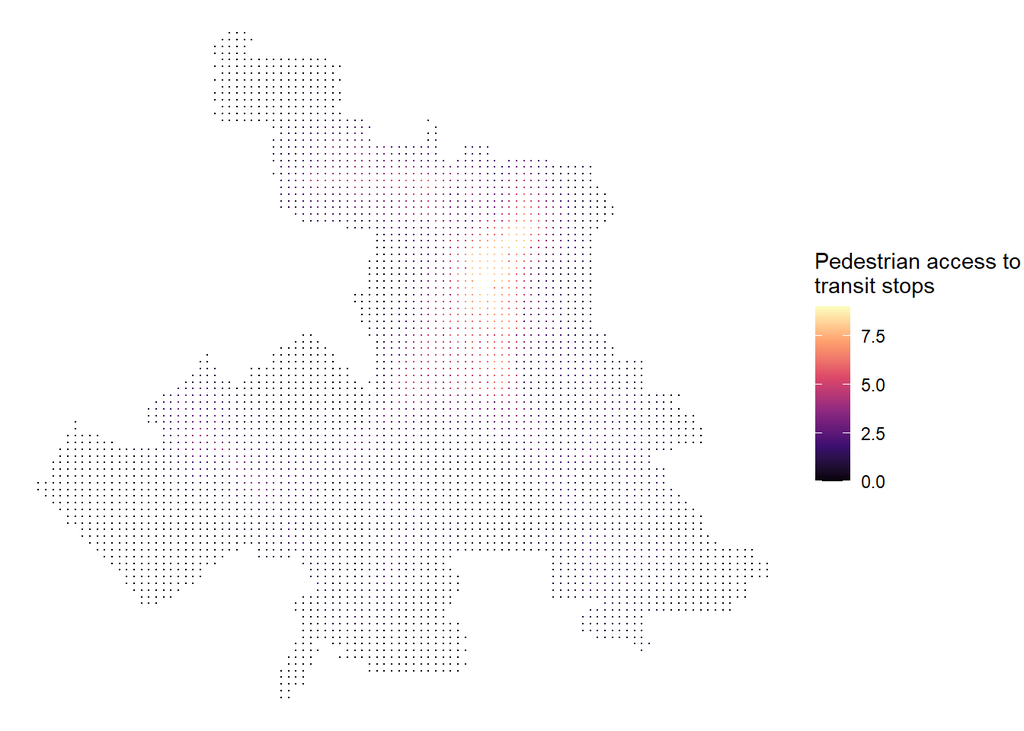

```r
access_points <- st_as_sf(access_raster, as_points = TRUE)

ggplot(SLO_streets) +
  geom_sf(data = access_points, aes(color = accessibility), size = 0.1) +
  scale_color_viridis_c(na.value = NA,
                       option="A",
                       name = "Pedestrian access to\ntransit stops") +
  theme_void()
```

## Polygons from grid cells

I can also create a polygon from each grid cell. This would essentially just recreate the polygon layer I used to create the raster initially, but on a square grid rather that a hexagonal grid. I can also set `merge=TRUE` so that adjacent areas with the same value are merged into a single polygon.

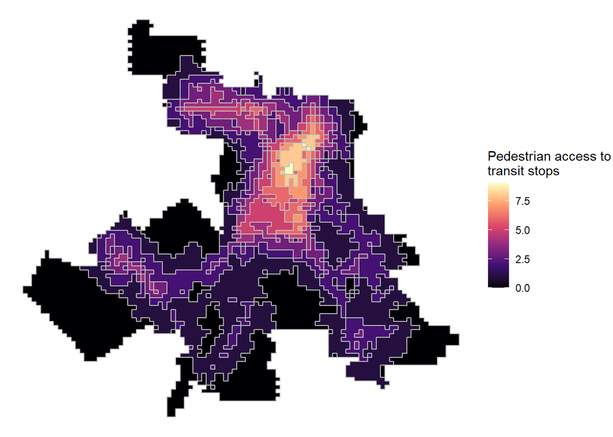

```r
access_poly2 <- st_as_sf(access_raster, as_points = FALSE, merge = TRUE)

ggplot(SLO_streets) +
  geom_sf(data = access_poly2, aes(fill = accessibility), color = 'gray') +
  scale_fill_viridis_c(na.value = NA,
                       option="A",
                       name = "Pedestrian access to\ntransit stops") +
  theme_void()
```

## Contours

In the example above, the polygon boundaries appear as countours. I can also just create contours directly from the raster.

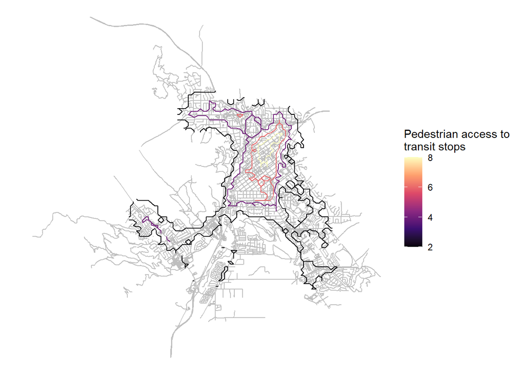

```r
access_contours <- st_contour(access_raster, contour_lines = TRUE,
                              breaks = c(0,2,4,6,8))

ggplot(SLO_streets) +
  geom_sf(color = "gray") +
  geom_sf(data = access_contours, aes(color = accessibility), fill = NA) +
  scale_color_viridis_c(na.value = NA,
                       option="A",
                       breaks = c(0,2,4,6,8),
                       name = "Pedestrian access to\ntransit stops") +
  theme_void()
```